# **Convolutional Neural Networks**

### **Baseline model building**

Specifications are as follows:

1. First convolutional layer: 64 filters (kernels) (3x3), ReLU as activation function, padding set to "same", and a MaxPooling layer (2x2) with padding.
2. Second convolutional layer: 64 filters (kernels) (3x3), ReLU as activation function, padding set to "same", and a MaxPooling layer (2x2) with padding.
3. Feedforward layer: one hidden layer with 120 neurons, ReLU as activation function.
4. Compilation: Adam optimizer with a learning rate of 0.001, categorical cross-entropy as the loss function, and accuracy as the performance metric.
5. Train for 10 epochs with a batch size of 32 and a validation split of 10%.

```python
np.random.seed(42)
import random
random.seed(42)
tf.random.set_seed(42)
```

```python
model_1 = Sequential()

# first convolutional layer
model_1.add(Conv2D(64, (3, 3), padding='same', activation='relu', input_shape=(32, 32, 3)))
model_1.add(MaxPooling2D(pool_size=(2, 2), padding='same'))

# second convolutional layer
model_1.add(Conv2D(64, (3, 3), padding='same', activation='relu'))
model_1.add(MaxPooling2D(pool_size=(2, 2), padding='same'))

model_1.add(Flatten())

# feedforward layer
model_1.add(Dense(120, activation='relu'))

# output layer
model_1.add(Dense(10, activation='softmax'))
```

```python
model_1.summary()
```

```
Model: "sequential_1"
```

```
┏━━━━━━━━━━━━━━━━━━━━━━━━━━━━━━━━━━━━━━┳━━━━━━━━━━━━━━━━━━━━━━━━━━━━━┳━━━━━━━━━━━━━━━━━┓
┃ Layer (type)                         ┃ Output Shape                ┃         Param # ┃
┡━━━━━━━━━━━━━━━━━━━━━━━━━━━━━━━━━━━━━━╇━━━━━━━━━━━━━━━━━━━━━━━━━━━━━╇━━━━━━━━━━━━━━━━━┩
│ conv2d_2 (Conv2D)                    │ (None, 32, 32, 64)          │           1,792 │
├──────────────────────────────────────┼─────────────────────────────┼─────────────────┤
│ max_pooling2d_1 (MaxPooling2D)       │ (None, 16, 16, 64)          │               0 │
├──────────────────────────────────────┼─────────────────────────────┼─────────────────┤
│ conv2d_3 (Conv2D)                    │ (None, 16, 16, 64)          │          36,928 │
├──────────────────────────────────────┼─────────────────────────────┼─────────────────┤
│ max_pooling2d_2 (MaxPooling2D)       │ (None, 8, 8, 64)            │               0 │
├──────────────────────────────────────┼─────────────────────────────┼─────────────────┤
│ flatten_1 (Flatten)                  │ (None, 4096)                │               0 │
├──────────────────────────────────────┼─────────────────────────────┼─────────────────┤
│ dense_2 (Dense)                      │ (None, 120)                 │         491,640 │
├──────────────────────────────────────┼─────────────────────────────┼─────────────────┤
│ dense_3 (Dense)                      │ (None, 10)                  │           1,210 │
└──────────────────────────────────────┴─────────────────────────────┴─────────────────┘
```

```
 Total params: 531,570 (2.03 MB)
```

```
 Trainable params: 531,570 (2.03 MB)
```

```
 Non-trainable params: 0 (0.00 B)
```

```python
opt = Adam(learning_rate=0.001)
model_1.compile(optimizer=opt, loss='categorical_crossentropy', metrics=['accuracy'])
```

```python
history_1 = model_1.fit(
    x_train_normalized, y_train_encoded,
    epochs=10,
    batch_size=32,
    validation_split=0.1
)
```

```
1407/1407 ━━━━━━━━━━━━━━━━━━━━ 8s 4ms/step - accuracy: 0.3943 - loss: 1.6597 - val_accuracy: 0.6140 - val_loss: 1.1069
1407/1407 ━━━━━━━━━━━━━━━━━━━━ 4s 3ms/step - accuracy: 0.6288 - loss: 1.0525 - val_accuracy: 0.6666 - val_loss: 0.9556
1407/1407 ━━━━━━━━━━━━━━━━━━━━ 6s 3ms/step - accuracy: 0.6851 - loss: 0.8908 - val_accuracy: 0.6900 - val_loss: 0.9098
1407/1407 ━━━━━━━━━━━━━━━━━━━━ 4s 3ms/step - accuracy: 0.7276 - loss: 0.7788 - val_accuracy: 0.6896 - val_loss: 0.9051
1407/1407 ━━━━━━━━━━━━━━━━━━━━ 5s 3ms/step - accuracy: 0.7602 - loss: 0.6856 - val_accuracy: 0.6888 - val_loss: 0.9504
1407/1407 ━━━━━━━━━━━━━━━━━━━━ 4s 3ms/step - accuracy: 0.7924 - loss: 0.6000 - val_accuracy: 0.6896 - val_loss: 1.0184
1407/1407 ━━━━━━━━━━━━━━━━━━━━ 5s 3ms/step - accuracy: 0.8196 - loss: 0.5194 - val_accuracy: 0.6904 - val_loss: 1.0923
1407/1407 ━━━━━━━━━━━━━━━━━━━━ 5s 3ms/step - accuracy: 0.8392 - loss: 0.4562 - val_accuracy: 0.6886 - val_loss: 1.1911
1407/1407 ━━━━━━━━━━━━━━━━━━━━ 4s 3ms/step - accuracy: 0.8625 - loss: 0.3962 - val_accuracy: 0.6624 - val_loss: 1.3282
1407/1407 ━━━━━━━━━━━━━━━━━━━━ 4s 3ms/step - accuracy: 0.8756 - loss: 0.3506 - val_accuracy: 0.6670 - val_loss: 1.3608
```

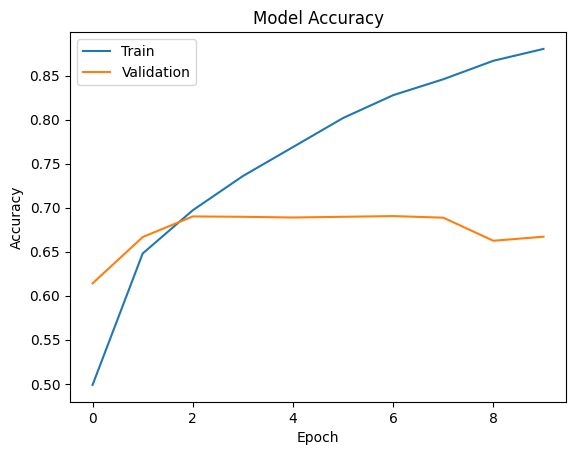

```python
# the graph of training and validation accuracy across epochs
plt.plot(history_1.history['accuracy'])
plt.plot(history_1.history['val_accuracy'])
plt.title('Model Accuracy')
plt.ylabel('Accuracy')
plt.xlabel('Epoch')
plt.legend(['Train', 'Validation'], loc='upper left')
plt.show()
```

```python
model_1.evaluate(x_test_normalized, y_test_encoded)
```

```
313/313 ━━━━━━━━━━━━━━━━━━━━ 1s 4ms/step - accuracy: 0.6554 - loss: 1.4340
```

```
[1.4535472393035889, 0.6500999927520752]
```

Clearing backend and fixing random seed to 42

```python
from tensorflow.keras import backend
backend.clear_session()
```

```python
np.random.seed(42)
import random
random.seed(42)
tf.random.set_seed(42)
```

### **Enhanced model**

```python
model_2 = Sequential()

# first convolutional layer
model_2.add(Conv2D(128, (3, 3), padding='same', activation='relu', input_shape=(32, 32, 3)))

# second convolutional layer
model_2.add(Conv2D(64, (3, 3), padding='same', activation='relu'))
model_2.add(MaxPooling2D(pool_size=(2, 2), padding='same'))

# third convolutional layer
model_2.add(Conv2D(32, (3, 3), padding='same', activation='relu'))
model_2.add(MaxPooling2D((2,2), padding='same'))

model_2.add(Flatten())

# feedforward layers
model_2.add(Dense(128, activation='relu'))
model_2.add(Dropout(0.025))

model_2.add(Dense(64, activation='relu'))

# output layer
model_2.add(Dense(10, activation='softmax'))

opt = Adam(learning_rate=0.001)
```

```python
model_2.summary()
```

```
Model: "sequential_1"
```

```
┏━━━━━━━━━━━━━━━━━━━━━━━━━━━━━━━━━━━━━━┳━━━━━━━━━━━━━━━━━━━━━━━━━━━━━┳━━━━━━━━━━━━━━━━━┓
┃ Layer (type)                         ┃ Output Shape                ┃         Param # ┃
┡━━━━━━━━━━━━━━━━━━━━━━━━━━━━━━━━━━━━━━╇━━━━━━━━━━━━━━━━━━━━━━━━━━━━━╇━━━━━━━━━━━━━━━━━┩
│ conv2d_2 (Conv2D)                    │ (None, 32, 32, 128)         │           3,584 │
├──────────────────────────────────────┼─────────────────────────────┼─────────────────┤
│ conv2d_3 (Conv2D)                    │ (None, 32, 32, 64)          │          73,792 │
├──────────────────────────────────────┼─────────────────────────────┼─────────────────┤
│ max_pooling2d (MaxPooling2D)         │ (None, 16, 16, 64)          │               0 │
├──────────────────────────────────────┼─────────────────────────────┼─────────────────┤
│ conv2d_4 (Conv2D)                    │ (None, 16, 16, 32)          │          18,464 │
├──────────────────────────────────────┼─────────────────────────────┼─────────────────┤
│ max_pooling2d_1 (MaxPooling2D)       │ (None, 8, 8, 32)            │               0 │
├──────────────────────────────────────┼─────────────────────────────┼─────────────────┤
│ flatten (Flatten)                    │ (None, 2048)                │               0 │
├──────────────────────────────────────┼─────────────────────────────┼─────────────────┤
│ dense (Dense)                        │ (None, 128)                 │         262,272 │
├──────────────────────────────────────┼─────────────────────────────┼─────────────────┤
│ dropout (Dropout)                    │ (None, 128)                 │               0 │
├──────────────────────────────────────┼─────────────────────────────┼─────────────────┤
│ dense_1 (Dense)                      │ (None, 64)                  │           8,256 │
├──────────────────────────────────────┼─────────────────────────────┼─────────────────┤
│ dense_2 (Dense)                      │ (None, 10)                  │             650 │
└──────────────────────────────────────┴─────────────────────────────┴─────────────────┘
```

```
 Total params: 367,018 (1.40 MB)
```

```
 Trainable params: 367,018 (1.40 MB)
```

```
 Non-trainable params: 0 (0.00 B)
```

```python
model_2.compile(
    loss='categorical_crossentropy',
    optimizer=opt,
    metrics=['accuracy']
)
```

```python
history_2 = model_2.fit(
    x_train_normalized, y_train_encoded,
    epochs=10,
    batch_size=32,
    validation_split=0.1
)
```

```
1407/1407 ━━━━━━━━━━━━━━━━━━━━ 16s 9ms/step - accuracy: 0.3629 - loss: 1.7354 - val_accuracy: 0.5838 - val_loss: 1.1732
1407/1407 ━━━━━━━━━━━━━━━━━━━━ 8s 6ms/step - accuracy: 0.6041 - loss: 1.1196 - val_accuracy: 0.6442 - val_loss: 1.0216
1407/1407 ━━━━━━━━━━━━━━━━━━━━ 10s 5ms/step - accuracy: 0.6743 - loss: 0.9177 - val_accuracy: 0.6842 - val_loss: 0.8966
1407/1407 ━━━━━━━━━━━━━━━━━━━━ 8s 6ms/step - accuracy: 0.7249 - loss: 0.7787 - val_accuracy: 0.6954 - val_loss: 0.8875
1407/1407 ━━━━━━━━━━━━━━━━━━━━ 9s 7ms/step - accuracy: 0.7614 - loss: 0.6747 - val_accuracy: 0.6732 - val_loss: 0.9681
1407/1407 ━━━━━━━━━━━━━━━━━━━━ 9s 5ms/step - accuracy: 0.7854 - loss: 0.5974 - val_accuracy: 0.6790 - val_loss: 1.0175
1407/1407 ━━━━━━━━━━━━━━━━━━━━ 12s 6ms/step - accuracy: 0.8127 - loss: 0.5249 - val_accuracy: 0.6840 - val_loss: 1.0762
1407/1407 ━━━━━━━━━━━━━━━━━━━━ 9s 7ms/step - accuracy: 0.8280 - loss: 0.4763 - val_accuracy: 0.6846 - val_loss: 1.1603
1407/1407 ━━━━━━━━━━━━━━━━━━━━ 11s 8ms/step - accuracy: 0.8445 - loss: 0.4320 - val_accuracy: 0.6920 - val_loss: 1.2152
1407/1407 ━━━━━━━━━━━━━━━━━━━━ 8s 6ms/step - accuracy: 0.8651 - loss: 0.3783 - val_accuracy: 0.6860 - val_loss: 1.3326
```

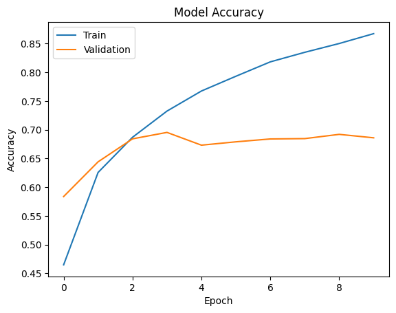

```python
# the graph of training and validation accuracy across epochs
plt.plot(history_2.history['accuracy'])
plt.plot(history_2.history['val_accuracy'])
plt.title('Model Accuracy')
plt.ylabel('Accuracy')
plt.xlabel('Epoch')
plt.legend(['Train', 'Validation'], loc='upper left')
plt.show()
```

```python
model_2.evaluate(x_test_normalized, y_test_encoded)
```

```
313/313 ━━━━━━━━━━━━━━━━━━━━ 1s 5ms/step - accuracy: 0.6656 - loss: 1.3484
```

```
[1.3717248439788818, 0.6668999791145325]
```

```python
y_pred_test = model_2.predict(x_test_normalized)

y_pred_test_classes = np.argmax(y_pred_test, axis = 1)

y_pred_test_max_probas = np.max(y_pred_test, axis=1)
```

```
313/313 ━━━━━━━━━━━━━━━━━━━━ 1s 2ms/step
```

```python
from sklearn.metrics import classification_report, confusion_matrix

print(classification_report(y_test, y_pred_test_classes))
```

```
              precision    recall  f1-score   support

           0       0.70      0.74      0.72      1000
           1       0.77      0.82      0.80      1000
           2       0.68      0.43      0.53      1000
           3       0.48      0.43      0.45      1000
           4       0.53      0.76      0.62      1000
           5       0.56      0.54      0.55      1000
           6       0.84      0.63      0.72      1000
           7       0.65      0.78      0.71      1000
           8       0.77      0.80      0.79      1000
           9       0.79      0.74      0.76      1000

    accuracy                           0.67     10000
   macro avg       0.67      0.67      0.66     10000
weighted avg       0.67      0.67      0.66     10000
```

```python
num_classes = 10
cifar10_classes = ["airplane", "automobile", "bird", "cat", "deer", "dog", "frog", "horse", "ship", "truck"]
```

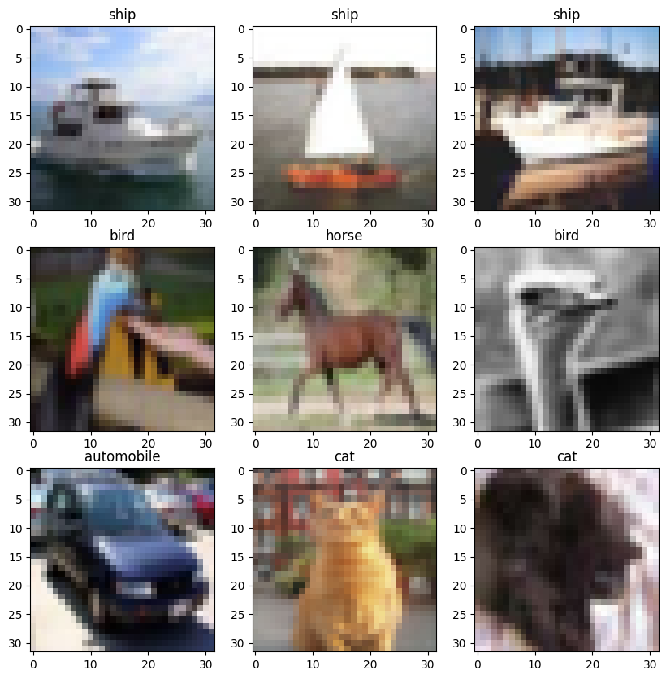

```python
rows = 3
cols = 3

fig = plt.figure(figsize=(10, 10))

for i in range(cols):
  for j in range(rows):
    random_index = np.random.randint(0, len(y_train))
    ax = fig.add_subplot(rows, cols, i * rows + j + 1)
    ax.imshow(x_train[random_index, :])
    ax.set_title(cifar10_classes[y_train[random_index, 0]])
plt.show();
pass
```

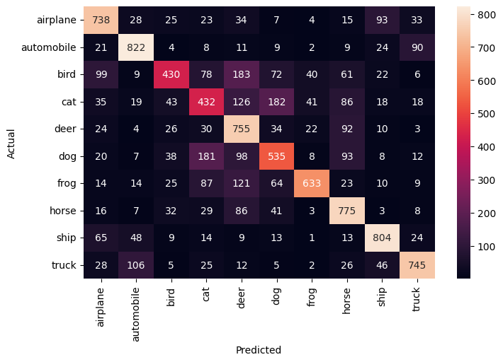

```python
cm = confusion_matrix(y_test, y_pred_test_classes)
plt.figure(figsize=(8,5))
sns.heatmap(cm, annot=True, fmt='.0f', xticklabels=cifar10_classes, yticklabels=cifar10_classes)
plt.ylabel('Actual')
plt.xlabel('Predicted')
plt.show()
```

### **Predicting Truck image**

[figure not shown]

```python
rows = 4
cols = 4

fig = plt.figure(figsize=(10,12))

for i in range(cols):
  for j in range(rows):
    random_index = np.random.randint(0, len(y_test))
    ax = fig.add_subplot(rows, cols, i * rows + j + 1)
    ax.imshow(x_test[random_index, :])
    pred_label = cifar10_classes[y_pred_test_classes[random_index]]
    pred_proba = y_pred_test_max_probas[random_index]
    true_label = cifar10_classes[y_test[random_index, 0]]
    ax.set_title("Actual: {}\n Predicted: {}\n Prob: {:.2f}".format(true_label, pred_label, pred_proba))
plt.show();
pass
```

```python
from google.colab import files
uploaded = files.upload()
```

Upload widget is only available when the cell has been executed in the current browser session. Please rerun this cell to enable.

```
Saving truck.jpg to truck.jpg
```

```
1/1 ━━━━━━━━━━━━━━━━━━━━ 1s 1s/step
```

```
matplotlib.pyplot.show
def show(*args, **kwargs)
```

[output not shown]

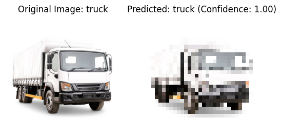

```python
from tensorflow.keras.preprocessing import image
import matplotlib.pyplot as plt

labels = ["airplane", "automobile", "bird", "cat", "deer", "dog", "frog", "horse", "ship", "truck"]

original_img = image.load_img('truck.jpg')

plt.subplot(1, 2, 1)
plt.imshow(original_img)
plt.title('Original Image: truck')
plt.axis('off')

img_path = 'truck.jpg'
img = image.load_img(img_path, target_size=(32, 32))

img_array = image.img_to_array(img)
img_array_normalized = img_array/255.0
img_array = np.expand_dims(img_array_normalized, axis=0)

y_pred = model_2.predict(img_array)

predicted_class_index = np.argmax(y_pred, axis=1)[0]
predicted_proba = np.max(y_pred)
predicted_label = labels[predicted_class_index]

plt.subplot(1, 2, 2)
plt.imshow(img)
plt.title(f"Predicted: {predicted_label} (Confidence: {predicted_proba:.2f})")
plt.axis('off')

plt.show
```

### **Answering the questions**

1. **Overall Accuracy on Test Set for Baseline and Improved Models**

   The overall accuracy for the baseline model is around 65% on the test set-from the evaluation summary, where the accuracy is 0.65-for the enhanced model, it improves a bit to attain an accuracy of around 67%. Since such an improvement does indicate that the enhanced model may do somewhat better by adjusting such factors as adding layers, dropout for regularization, or architecture changes, see model summaries.

   Although small, the gain in accuracy depicts that the enhanced model will slightly generalize better on unseen data. This gain is modest, which, in fact, depicts that further tuning might be required, or probably different strategies may be taken to make a marked difference in the model's performance.
2. **Recall and Individual Accuracy for Trucks in the Enhanced Model**

The recall metric, which basically tells how good the model is at identifying positive instances of the class, shows difference across classes. To be more precise, for trucks, the individual accuracy seems to be comparatively high; that can be made out by the number of truck images correctly classified in the confusion matrix. On the other hand, the high probability score close to 1.0 for correctly classified truck images on the visual output also hints that the model has done a good job in learning trucks.

**Are These Results Acceptable?**

These results are somewhat acceptable but may not be ideal. This enhanced model showed better accuracy, and the performance in finding trucks was appropriate. Overall, the 67% model accuracy shows there is room for further improvement. For an application that needs a high precision, further improvements will be required. Increasing the training data, doing augmentation of data, or fine-tuning methods could help in further improving the model performance on all classes.

```python
# Install nbconvert if not already installed
!pip install nbconvert

# Convert the notebook to HTML
!jupyter nbconvert --to html "/content/Prudhvi_Veerla_MTE_S26.ipynb"

from google.colab import files
files.download("/content/Prudhvi_Veerla_MTE_S26.html")
```

```
[NbConvertApp] Converting notebook /content/Prudhvi_Veerla_MTE_S26.ipynb to html
[NbConvertApp] WARNING | Alternative text is missing on 7 image(s).
[NbConvertApp] Writing 884915 bytes to /content/Prudhvi_Veerla_MTE_S26.html
```